# Lecture 10: Hypothesis testing

Mathematics and Statistics BS1515

Theodoros Arvanitopoulos

2025-12-08

# Learning outcomes

- Understand how to make decisions about the hypothesis tests.
- Formulate a decision rule for testing a hypothesis.
- Understand the concept of error and the different types of error in decision making.
- Know how to use the critical value and p-value approaches to test the null hypothesis.
- Know what Type I and Type II errors are.

### 📚 Reading

Newbold et al. (2020), *Statistics for Business and Economics*, Ch. 9

# Hypothesis testing

A **hypothesis** is a claim (assumption) about a **population parameter**:

- *population mean*

e.g. The mean monthly cell phone bill of this city is $\mu=£52$

- *population proportion*

e.g. The proportion of adults in this city with cell phones is $P=0.88$

We use our **sample** to assess the truth or validity of some assertion about the population.

# The Null Hypothesis $(H_0)$ vs the Alternative Hypothesis $(H_1)$

**Null Hypothesis $(H_0)$**

- States the **assumption** (numerical) to be tested → always about a population parameter not a sample statistic
- Begin with the assumption that the null hypothesis is **true**
- Refers to the **status quo**
- Always contains “=”, “≤” or “≥”
- May or may not be **rejected**

# The Null Hypothesis $(H_0)$ vs the Alternative Hypothesis $(H_1)$

**Null Hypothesis $(H_0)$**

- States the **assumption** (numerical) to be tested → always about a population parameter not a sample statistic
- Begin with the assumption that the null hypothesis is **true**
- Refers to the **status quo**
- Always contains “=”, “≤” or “≥”
- May or may not be **rejected**

**Alternative Hypothesis $(H_1)$**

- Opposite of the null hypothesis
- Challenges the **status quo**
- May or may not be **supported**
- Is generally the hypothesis that the researcher is trying to **support**

# Hypothesis testing process

1. Set up the hypotheses → what’s the value of the population parameter

e.g. Hypothesis: the population mean age is $50$ → $H_0$: $\mu=50$

# Hypothesis testing process

1. Set up the hypotheses → what’s the value of the population parameter

e.g. Hypothesis: the population mean age is $50$ → $H_0$: $\mu=50$

2. Set the significance level $\alpha$ → provides critical values of the test

e.g. to reject the null, traditionally researchers choose $\alpha=5\%$ (or $1-\alpha=95\%$)

# Hypothesis testing process

1. Set up the hypotheses → what’s the value of the population parameter

e.g. Hypothesis: the population mean age is $50$ → $H_0$: $\mu=50$

2. Set the significance level $\alpha$ → provides critical values of the test

e.g. to reject the null, traditionally researchers choose $\alpha=5\%$ (or $1-\alpha=95\%$)

3. Collect a random sample and compute test statistic

e.g. find data source and prepare data for analysis

# Hypothesis testing process

1. Set up the hypotheses → what’s the value of the population parameter

e.g. Hypothesis: the population mean age is $50$ → $H_0$: $\mu=50$

2. Set the significance level $\alpha$ → provides critical values of the test

e.g. to reject the null, traditionally researchers choose $\alpha=5\%$ (or $1-\alpha=95\%$)

3. Collect a random sample and compute test statistic

e.g. find data source and prepare data for analysis

4. Make decision: reject or do not reject $H_0$

e.g. if $H_0$ rejected, then $H_1$ true, meaning mean age is not $50$

# Hypothesis testing process - visual example

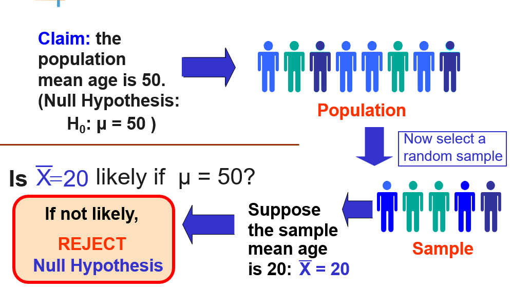

# Reasons for rejecting $H_0$ - visual example

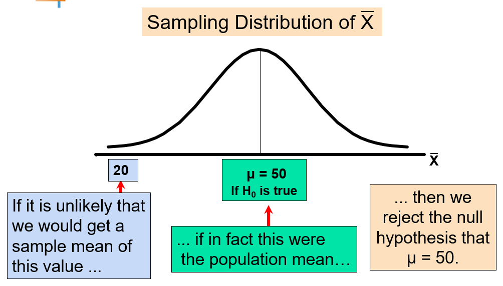

# Level of significance $\alpha$ and the rejection area

The level of significance defines the unlikely values of the sample statistic if the null hypothesis is true.

In other words, it defines **rejection region** of the sampling distribution.

So, rejection areas are designated by the level of significance → typical values of $\alpha$ : $0.01, 0.05, 0.10$.

$\alpha$ provides the critical values of the test the inform the research of when to reject the null $H_0$ and accept the alternative $H_1$

$$Confidence \ \ level = ( 1 -
\alpha)$$

# Level of significance $\alpha$ and the rejection area

The level of significance defines the unlikely values of the sample statistic if the null hypothesis is true.

In other words, it defines **rejection region** of the sampling distribution.

So, rejection areas are designated by the level of significance → typical values of $\alpha$ : $0.01, 0.05, 0.10$

$\alpha$ provides the critical values of the test the inform the research of when to reject the null $H_0$ and accept the alternative $H_1$

$$Confidence \ \ level = ( 1 -
\alpha)$$

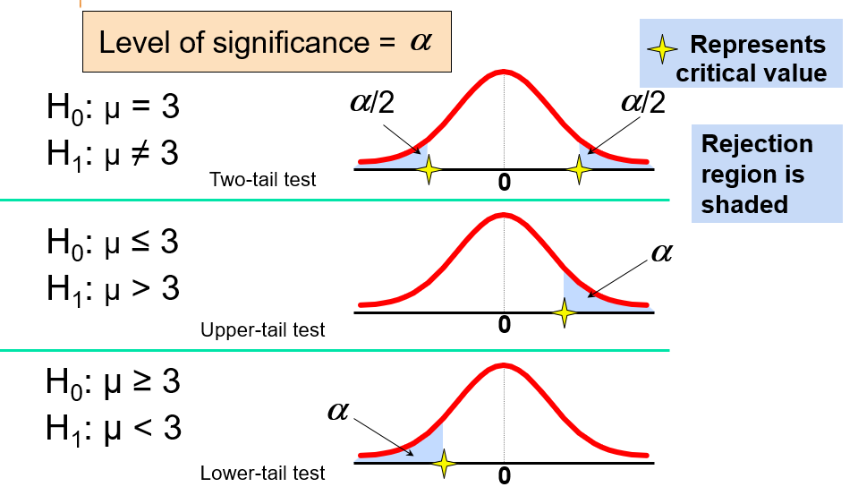

# Type I and Type II Errors

There are common errors in making decisions that we outline below.

**Type I error**:

- this happens when we reject a true null hypothesis → this is a serious error!
- the probability of Type I error is $\alpha$ and is called the level of significance of the test

**Type II error**:

- fail to reject a false null hypothesis
- the probability of Type II error is $\beta$, and $1-\beta$ the power of the test

# Possible hypothesis test outcomes and probabilities

| **Decision** | **$H_0$ True** | **$H_0$ False** |
| --- | --- | --- |
| Do not reject $H_0$ | Correct decision | Type II error ($\beta$) |
|  | (True negative) | (false negative) |
|  | Probability=$1-\alpha$ | Probability=$\beta$ |
| Reject $H_0$ | Type I error | Correct decision |
|  | (False positive) | (true positive) |
|  | Probability=$\alpha$ | Probability=$1-\beta$ |

# Type I and Type II Errors - example

### Example

Test to indicate whether someone is pregnant

- **$H_0$**: you are not pregnant
- **$H_1$**: you are pregnant

### Hypothesis testing

- **Type I error**: false positive indicates you are pregnant, when you’re not
- **Type II error**: false negative indicates you are not pregnant, when you are

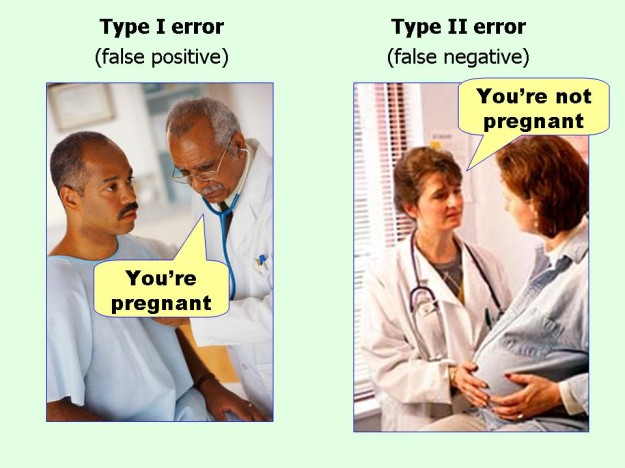

# Type I and II error relationship

Type I and Type II errors cannot happen at the same time

- Type I error can only occur if $H_0$ is true
- Type II error can only occur if $H_0$ is false

If Type I error probability ($\alpha$) ↑, then Type II error probability ($\beta$) ↓ → trade-off between Type I and II errors.

# Type I and II error relationship

Type I and Type II errors cannot happen at the same time

- Type I error can only occur if $H_0$ is true
- Type II error can only occur if $H_0$ is false

If Type I error probability ($\alpha$) ↑, then Type II error probability ($\beta$) ↓ → trade-off between Type I and II errors.

### Factors affecting type II error

Ceteris Paribus (all else equal)

- $\beta$ ↑ when the difference between hypothesised parameters and its true value ↓
- $\beta$ ↑when $\alpha$ ↓
- $\beta$ ↑when $\sigma$ ↑
- $\beta$ ↑when $n$ ↓

# Hypothesis tests for the mean

### Test statistic

If the sample statistic is far from the stated population parameter, the null hypothesis is rejected.

How far is “far enough” to reject $H_0$?

# Hypothesis tests for the mean

### Test statistic

If the sample statistic is far from the stated population parameter, the null hypothesis is rejected.

How far is “far enough” to reject $H_0$?

The test statistic is a sample statistic, computed from information provided in the sample.

The researcher uses the sample statistic to decide between the null $H_0$ and alternative $H_1$.

The power of the test is the probability of rejecting a null hypothesis $H_0$.

The power of the test increases as the sample size increases.

$$Power = P \ ( \ Reject \ \ H_0 \ | \
H_1 \ \ is \ \ true)$$
Test statistics for the mean differs when $\sigma$ is known ($Z$ statistic) vs when is unknown ($t$ statistic).

# Two-tailed type of test

Two-tailed test ($t$-stat or $z$-stat):

$H_0: \mu = \mu_0$ vs. $H_1: \mu \neq \mu_0$

- We assign half of $\alpha$ to test the statistical significance in either direction.
- This means that $0.025$ in each tail of the distribution of the test statistic.
- Regardless of the direction of the relationship hypothesised, the test is for the possibility of the relationship in both directions.

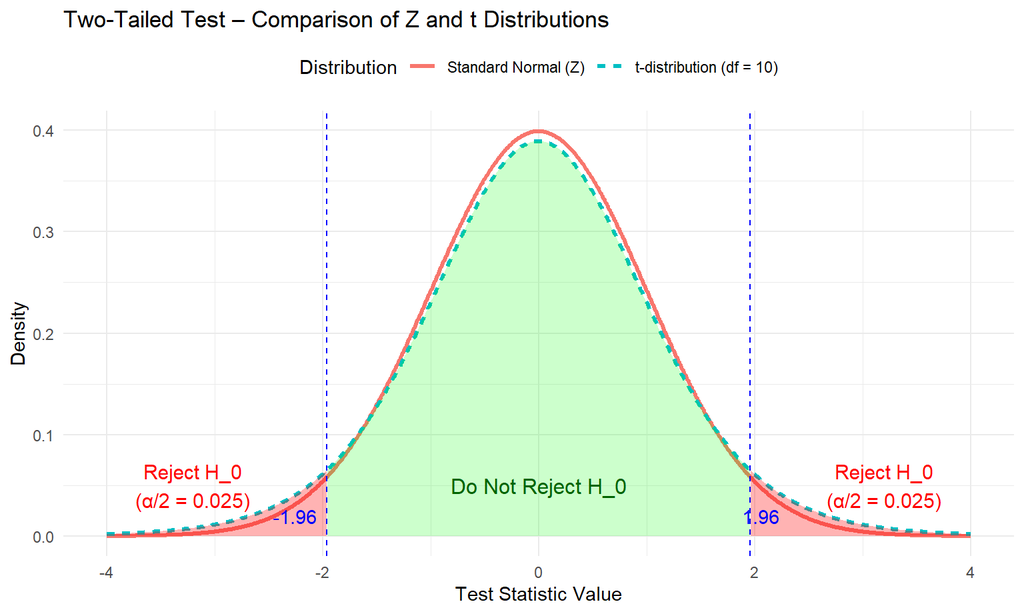

# $Z$-Test for the mean ($\sigma$ known)

We start with the case that $\sigma$ is known.

This means that we convert sample statistic $\bar{x}$ to a $Z-stat$ test statistic.

Assume the population is normal and consider the test:

$H_0$: $\mu=\mu_0$

$H_1$: $\mu \neq \mu_0$

The decision rule is:

Reject $H_0$ if $Z = \frac{\bar{x} - \mu_0}{\sigma / \sqrt{n}}< -z_{\alpha/2}$ or $Z = \frac{\bar{x} - \mu_0}{\sigma / \sqrt{n}}> z_{\alpha/2}$

where $z_{\alpha}$ is the critical value for $\alpha$ significance level

# $t$-Test for the mean ($\sigma$ uknown)

What if $\sigma$ is unknown?

This means that we convert sample statistic $\bar{x}$ to a $t-stat$ test statistic.

Assume the population is normal and consider the test:

$H_0$: $\mu=\mu_0$

$H_1$: $\mu \neq \mu_0$

The decision rule is:

Reject $H_0$ if $t=\frac{\bar{x} - \mu_0}{s / \sqrt{n}}<- t_{n-1, \ \alpha/2}$ or $t= \frac{\bar{x} - \mu_0}{s / \sqrt{n}}> t_{n-1, \ \alpha/2}$

where $t_{n-1, \ \alpha}$ is the critical value for d.f. $n-1$ and $\alpha$ significance level

# One-tailed type of test

**One-tailed (greater)** test ($t$-stat or $z$-stat):

$H_0: \mu \leq \mu_0$ vs. $H_1: \mu > \mu_0$

**One-tailed (less)** test ($t$-stat or $z$-stat):

$H_0: \mu \geq \mu_0$ vs. $H_1: \mu < \mu_0$

- We assign all $\alpha$ to testing the statistical significance in one direction.
- This means that $0.05$ is in one tail of the distribution of the test statistic.
- For one tailed test, you disregard the possibility of a relationship in the other direction.
- We rarely use one tailed tests as we do not know in advance if the values we are interested in should be above or below $\mu$

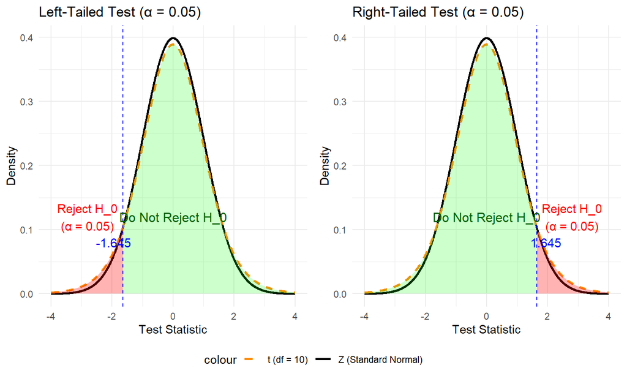

# Critical Value Approach (Two-Tailed Test)

### Step 1

Set up hypotheses (about the value of the parameter):

- Null hypothesis ($H_0$): a statement that parameter(s) take(s) specific values.
- Alternative hypothesis ($H_1$): states that parameter value(s) fall(s) in some alternative range of values.

### Step 2

Set the level of significance $\alpha$.

### Step 3

Calculate the test statistic and critical $t$-stat (same for $z$-stat)

### Step 4

Decide whether to accept or reject the Null Hypothesis $H_0$. Conclude that we reject $H_0$ if:

$$t > t_{\alpha/2, \ df} \quad \text{or} \quad t < -t_{\alpha/2, \
df}$$

# $p$-value approach to testing

**$p$-value** is the probability of obtaining a test statistic equal to or more extreme than the observed sample value given $H_0$ is true.

It is also called observed level of significance → researchers often say they found *“statistically significant findings”*.

**$p$-value** is the smallest value of $\alpha$ for which $H_0$ can be rejected.

In practice, this is the most common approach for deciding whether $H_0$ can be rejected, and you will find it widely reported in statistical software (Stata, R, etc).

# $p$-value approach to testing

**$p$-value** is the probability of obtaining a test statistic equal to or more extreme than the observed sample value given $H_0$ is true.

It is also called observed level of significance → researchers often say they found *“statistically significant findings”*.

**$p$-value** is the smallest value of $\alpha$ for which $H_0$ can be rejected.

In practice, this is the most common approach for deciding whether $H_0$ can be rejected, and you will find it widely reported in statistical software (Stata, R, etc).

To obtain the $p$-value for an upper tail test:

$$p-value = P(z> \frac{\bar{x}-\mu}{\sigma/\sqrt{n}}, \ \ given \ \
that \ \ H_0 \ \ is \ \ true) \\
= P(z> \frac{\bar{x}-\mu}{\sigma/\sqrt{n}} \ | \ \mu=\mu_0)$$

**Decision rule** : compare $p$-value to $\alpha$

- if $p$-value $< \alpha$, then reject $H_0$
- if $p$-value $> \alpha$, then do not reject $H_0$

# $p$-value example

### Decision rule

- $p < 0.10$: some evidence against $H_0$ but not accepted as robust evidence by applied researchers
- $p < 0.05$: strong evidence against $H_0$
- $p < 0.01$: very strong evidence against $H_0$

### Example

The example assumes a two-tailed test with a given test statistic and highlights the area of the $p$-value, visually comparing it to the significance level $\alpha=0.05$

The plot below illustrates rejection of the null hypothesis using the $p$-value approach. → $p$-value=$0.022$, and given $p<0.05$, then we reject $H_0$.

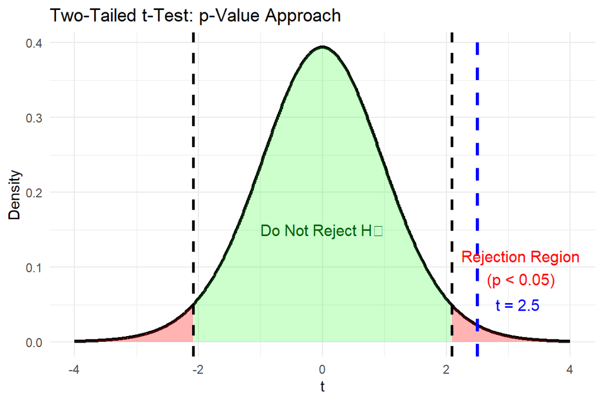